# Practice 9

Elena Tuzhilina

March 14, 2023

### Simulation in R

To generate a sample from a distribution we use functions with names that start with “r”.

Run the following code line to read the description of the functions.

```r
?rnorm
?rbinom
?rt
?runif
```

For example, the following code will generate a random sample of size $10$ from normal distribution $N(10,5^2)$

```r
rnorm(n = 10, mean = 10, sd = 5)
```

```
##  [1] 13.526189  7.407752  9.747115  8.478279 10.737673 11.421818 12.787931
##  [8] 11.078982 18.177772  8.676007
```

and the following code will generate a random sample of size $5$ from uniform distribution $Unif(-5,5)$.

```r
runif(n = 5, min = -5, max = 5)
```

```
## [1]  4.7700697 -0.9578752  1.9721777 -2.8716686  4.3980985
```

Now, try to generate a normal sample several times. Note that the generation process in R is random, so every time you get a new sample!

```r
rnorm(n = 10, mean = 10, sd = 5)
```

```
##  [1] -0.2861615  5.6289344  0.4543516 14.9408064  6.4048491 14.0050222
##  [7]  9.6469391  1.8574426 20.1448480  9.3619645
```

```r
rnorm(n = 10, mean = 10, sd = 5)
```

```
##  [1] -1.494979  4.612990 14.476594 16.594731  9.018690  7.131331 12.952268
##  [8]  8.826710 20.168714 12.100100
```

```r
rnorm(n = 10, mean = 10, sd = 5)
```

```
##  [1]  9.801491 12.520682  4.442353 11.609474  5.677155  2.491124  8.858177
##  [8]  7.751763  3.511956  8.032030
```

To create a random sample that can be reproduced we use `set.seed(...)` function, which sets the “seed” of the random number generator in R. Run the following code and make sure that you get exactly the same results as in this tutorial.

```r
set.seed(0)
rnorm(n = 10, mean = 10, sd = 5)
```

```
##  [1] 16.314771  8.368833 16.648996 16.362147 12.073207  2.300250  5.357165
##  [8]  8.526398  9.971164 22.023267
```

### Central Limit Theorem

In this part we will illustrate the Central Limit Theorem for samples generated from uniform distribution $Unif(0,10)$.

Recall that the density curve of this distribution looks like a “step” of width $10$ and height $0.1$.

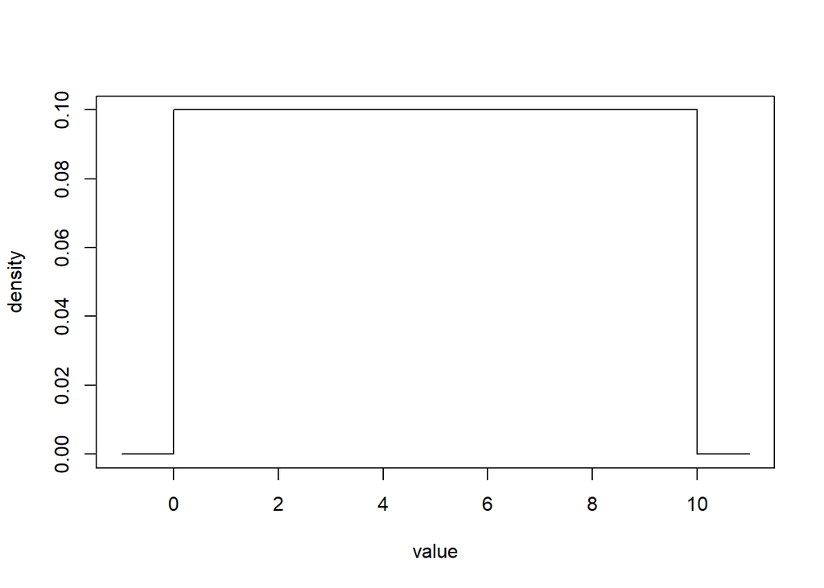

Let’s generate one large sample (of size $1000$) form $Unif(0,10)$ and plot the distribution histogram of the sample. It should look similar to the theoretical density.

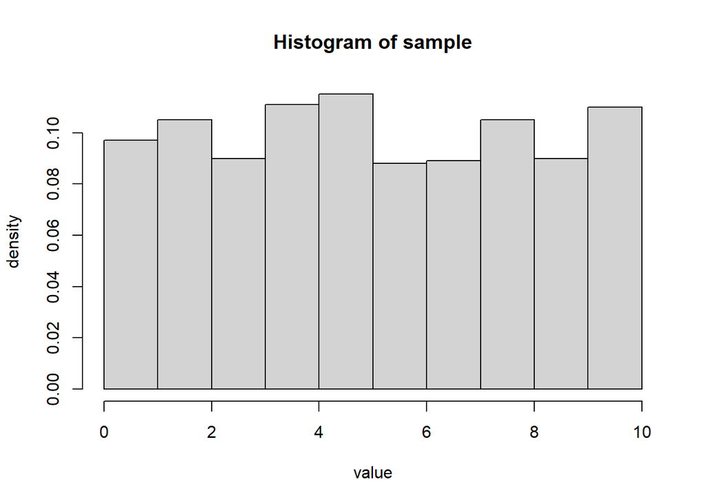

```r
sample = runif(n = 1000, min = 0, max = 10)
hist(sample, freq = FALSE, breaks = 10, xlab = "value", ylab = "density")
```

Also, recall that the theoretical values of the expectation and variance for a random variable $X\sim Unif(0,10)$ are $\mu=E(X) = \frac{10-0}{2} = 5$ and $\sigma^2=Var(X) = \frac{(10-0)^2}{12} = 8.3333$.

```r
mu = (10 - 0)/2
mu
```

```
## [1] 5
```

```r
sigma2 = (10 - 0)^2/12
sigma2
```

```
## [1] 8.333333
```

Let’s check if these values are consistent with the sample mean and variance.

```r
mean(sample)
```

```
## [1] 5.000792
```

```r
var(sample)
```

```
## [1] 8.355622
```

According to CLT, for large $n$ the distribution of the sample mean $\bar{X}$ is approximately normal $N(\mu, \frac{\sigma^2}{n})$, which, in our case, should be $N(5, \frac{8.3333}{1000})$.

In general, to find the values of a density curve, use functions that start with “d”, e.g.

```r
?dnorm
?dbinom
?dt
?dunif
```

To plot the theoretical CLT distribution we first select a grid of values where the density curve will be evaluated.

```r
grid = seq(4.5, 5.5, 0.01)
```

We use `dnorm(...)` function to find the value of the density curve of $N(5, \frac{8.3333}{1000})$ at each point of the grid.

```r
density = dnorm(x = grid, mean = mu, sd = sqrt(sigma2/1000))
```

Finally, we can plot the density curve.

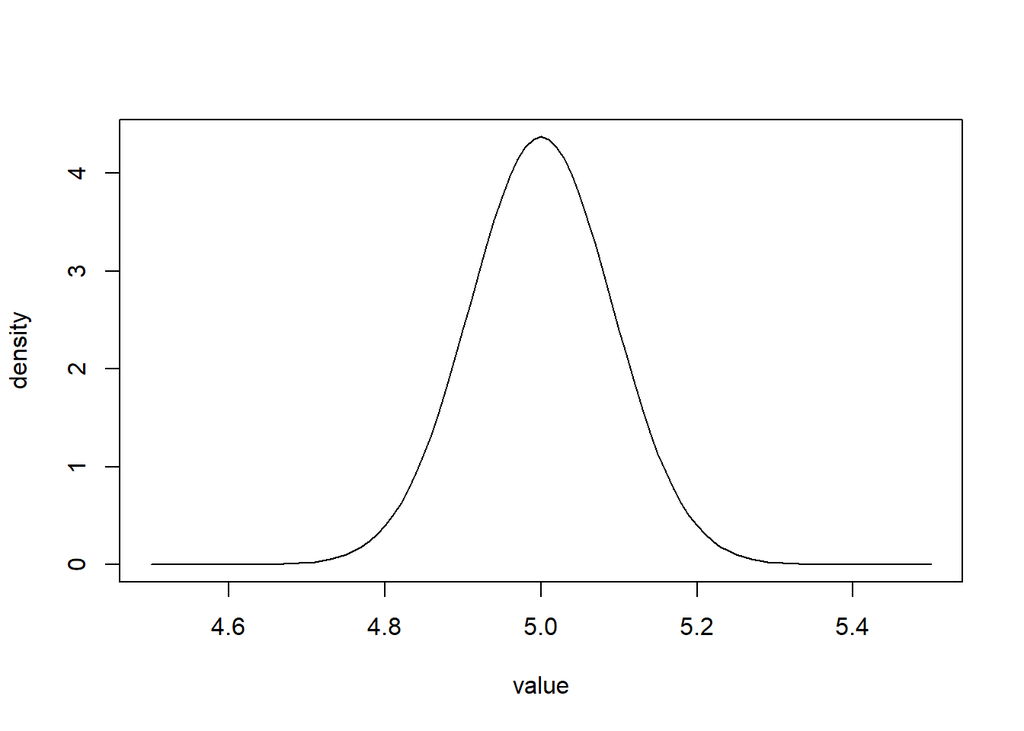

```r
plot(x = grid, y = density, type = 'l', xlab = "value", ylab = "density")
```

Let’s use the random sample generation to test the CLT statement for $n = 1000$. The following code generates one sample of size $1000$ form $Unif(0,10)$, and computes the mean of the sample.

```r
mean(runif(n = 1000, min = 0, max = 10))
```

```
## [1] 4.877456
```

Again, if you re-run the above line multiple times you will get different values of the sample mean (because every time R generates a sample at random), but all of these values will be close to the theoretical expectation $\mu = 5$.

```r
mean(runif(n = 1000, min = 0, max = 10))
```

```
## [1] 4.917563
```

```r
mean(runif(n = 1000, min = 0, max = 10))
```

```
## [1] 4.958312
```

```r
mean(runif(n = 1000, min = 0, max = 10))
```

```
## [1] 5.076849
```

Instead of copy-pasting the code three times, we can use `replicate(...)` function. Read the description of this function first:

```r
?replicate
```

Essentially, `replicate(n = ..., expr = ...)` function re-runs the code in the `expr` argument `n` times. For instance, the following line will return 500 sample means, where each of the sample was generated from the uniform distribution.

```r
sample_means = replicate(n = 500, expr = mean(runif(n = 1000, min = 0, max = 10)))
sample_means
```

```
##   [1] 5.217300 5.165422 4.843427 5.018413 4.933646 5.076321 4.967200 4.927972
##   [9] 4.961912 5.005764 5.085939 4.775069 5.064276 5.088605 5.104516 4.983642
##  [17] 4.997396 4.905318 4.942314 4.872744 4.944496 4.980214 5.134307 4.843706
##  [25] 5.024972 5.011016 5.072923 5.041315 5.077371 5.019578 5.013767 4.930861
##  [33] 5.063024 4.846047 4.950929 5.192180 5.078764 5.103997 4.992412 4.921227
##  [41] 5.016025 4.968691 5.075156 5.132415 5.030373 5.094945 4.976904 4.915074
##  [49] 5.008027 4.982038 5.083267 5.101863 5.025579 4.954598 4.898961 5.084326
##  [57] 5.008723 5.047986 5.159624 5.033511 5.036293 5.059429 4.934431 4.933351
##  [65] 4.924253 5.069015 5.052752 5.057084 4.876199 4.925773 4.908488 4.998751
##  [73] 5.036396 4.947899 4.905555 4.940761 4.970123 4.938482 4.963757 5.101469
##  [81] 5.004796 4.953499 5.076905 4.921984 4.954352 4.936210 4.752722 5.027816
##  [89] 5.121969 4.921153 5.125787 4.938181 4.988424 4.905817 4.993227 4.937918
##  [97] 5.121506 4.925657 5.233869 4.945638 4.918882 4.996280 5.007090 4.941755
## [105] 4.965421 5.027092 5.152457 5.021611 4.769466 4.927260 4.914808 5.138121
## [113] 5.062017 4.921519 5.003714 5.038364 5.027586 5.065542 5.065774 4.968919
```

[output cut: 48 more lines]

Let’s plot the density histogram for the sample means (we use `xlim =` argument to set x-axis limits and make them compatible to the ones in the density curve plot).

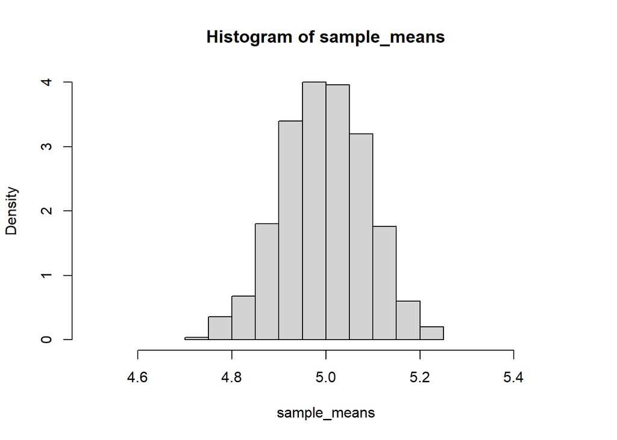

```r
hist(sample_means, freq = FALSE, breaks = 15, xlim = c(4.5, 5.5))
```

You can also add the CLT density curve to the plot using `lines(...)` function.

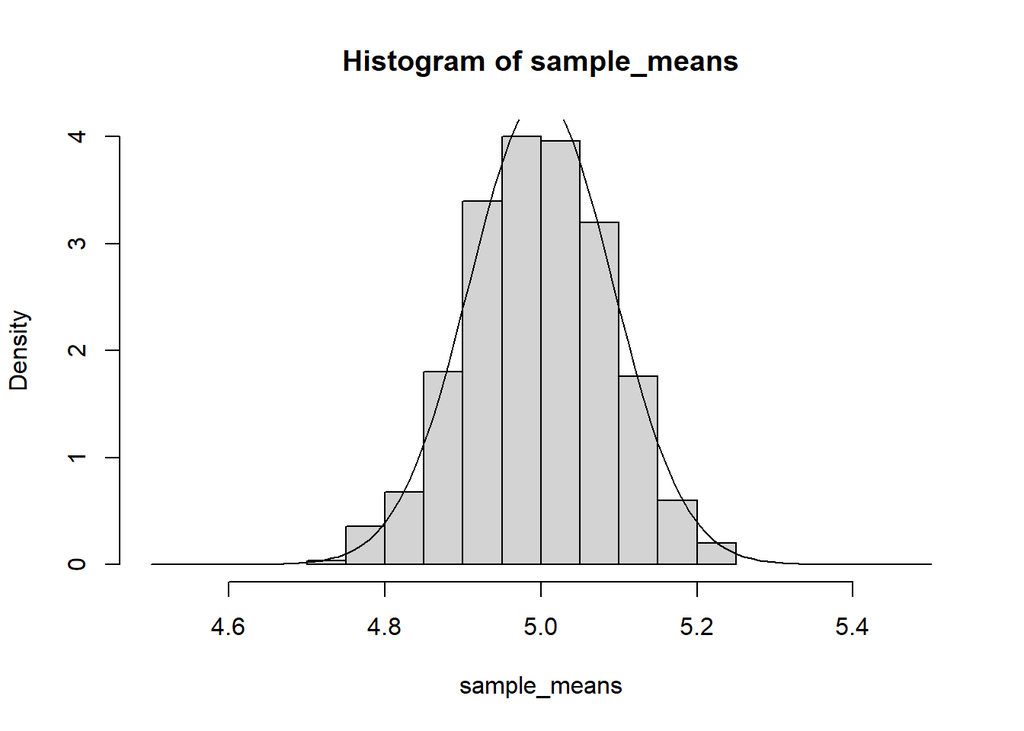

```r
hist(sample_means, freq = FALSE, breaks = 15, xlim = c(4.5, 5.5))
lines(x = grid, y = density)
```

The density histogram looks like a normal distribution!

Finally, we check that the expectation and variance of the distribution histogram are consistent with $\mu =5$ and $\frac{\sigma^2}n=\frac{8.3333}{1000}$.

```r
mean(sample_means)
```

```
## [1] 4.996577
```

```r
var(sample_means)
```

```
## [1] 0.008113006
```

### Find probabilities

To find a probability $P(X\leq q)$ we use functions that start with “p”.

```r
?pnorm
?pbinom
?pt
?punif
```

For example, the following function will find the probability $P(X\leq -1)$ where $X\sim N(10, 5^2).$ (Use the normal distribution table form Quercus to check this result)

```r
pnorm(q = -1, mean = 10, sd = 5)
```

```
## [1] 0.01390345
```

If you want to find $P(X\geq q)$ instead, set `lower.tail = FALSE`.

```r
pnorm(q = -1, mean = 10, sd = 5, lower.tail = FALSE)
```

```
## [1] 0.9860966
```

To solve the reverse problem (find a quantile of a distribution, e.g. value $a$ such that $P(X\leq a) = 0.25$) we use functions that start with “q”.

```r
?qnorm
?qbinom
?qt
?qunif
```

For example, the following function will find the 25-th percentile of t-distribution with 10 degrees of freedom. (Use the t-distribution table form Quercus to find this quantile and compare this result to the R output)

```r
qt(0.25, df = 10)
```

```
## [1] -0.6998121
```

### Statistical testing

In this part we will learn how to do statistical testing in R.

First, let’s generate a sample.

```r
set.seed(0)
sample = rnorm(30, 0, 1)
sample
```

```
##  [1]  1.262954285 -0.326233361  1.329799263  1.272429321  0.414641434
##  [6] -1.539950042 -0.928567035 -0.294720447 -0.005767173  2.404653389
## [11]  0.763593461 -0.799009249 -1.147657009 -0.289461574 -0.299215118
## [16] -0.411510833  0.252223448 -0.891921127  0.435683299 -1.237538422
## [21] -0.224267885  0.377395646  0.133336361  0.804189510 -0.057106774
## [26]  0.503607972  1.085769362 -0.690953840 -1.284599354  0.046726172
```

To conduct statistical testing for the population mean $\mu$ we use `t.test(...)` function.

```r
?t.test
```

The following code will use `sample` to check $H_0: \mu = 0$ vs. $H_a: \mu \neq 0$.

Note that you can use

- `alternative =` argument to switch between one- and two-sided alternatives;
- `conf.level =` argument to change the significance level $\alpha$.

```r
t.test(x = sample, alternative = "two.sided", mu = 0, conf.level = 0.95)
```

```
##
##  One Sample t-test
##
## data:  sample
## t = 0.13152, df = 29, p-value = 0.8963
## alternative hypothesis: true mean is not equal to 0
## 95 percent confidence interval:
##  -0.3193943  0.3632959
## sample estimates:
##  mean of x
## 0.02195079
```

In the output of `t.test(...)` function you get the following information:

- the sample mean $\bar{x} = 0.02195079$
- the value of the test statistic $t_{obs} = 0.13152$
- the *p-value* $= 0.8963$
- BONUS: the confidence interval for $\mu$ [-0.3193943, 0.3632959]!

To run statistical testing for proportions we use `binom.test(...)` function. Note that, in this case, argument `x =` corresponds to the “number of successes” and `n =` is the “number of trials”.

```r
binom.test(x = 65, n = 100, p = 0.5, alternative = "greater", conf.level = 0.8)
```

```
##
##  Exact binomial test
##
## data:  65 and 100
## number of successes = 65, number of trials = 100, p-value = 0.001759
## alternative hypothesis: true probability of success is greater than 0.5
## 80 percent confidence interval:
##  0.6037246 1.0000000
## sample estimates:
## probability of success
##                   0.65
```

Tn the output of `binom.test(...)` function you get:

- the sample mean $\bar{x} = 0.65$
- the *p-value* $= 0.001759$
- BONUS: the confidence interval for $p$ [0.6037246 1.0000000]!